# Script

Mariana Rius

4/24/2020

# Setup

1. Install on your own computer:

[R](https://www.r-project.org/)

[RStudio](https://rstudio.com/products/rstudio/download/)

1. In console run:

```r
knitr::opts_knit$set(root.dir = 'C:/Users/alexg/Google Drive/05-Proyectos/restlab_workshop/MarianaRius')
```

install.packages(“readxl”) install.packages(“rlist”) install.packages(“growthcurver”) install.packages(“dplyr”) install.packages(“ggplot2”)

1. Download datasets or locate your own data you would like to use.

# Datasets provided:

## LAA-E2.xlsx

- OD data - Single reads per well
- LAA = Laby Antibiotic Assay
  - [plate setup](https://docs.google.com/presentation/d/1jRHy32pm0gParXaoHVKo8pyVgZAvbHmZJvZlcpzZYKc/edit?usp=sharing)
  - 96 wells
  - 16 time points
  - No media blank
- Excel file
  - sheets arranged reverse chronologically (most recent **first** )
  - OD reads start at row 27 (header = row 26)
  - Date and time on row 23
  - Last sheet is not blank

## NGE-E1-P3.xlsx

- OD Data - Multiple reads per well
- NGE = Nutrient Growth Experiment
  - [plate setup](https://docs.google.com/presentation/d/1Fe_pQ2ebTqtWHqC9wkUPmBWrXytWQm8loQvxyXw0EWs/edit?usp=sharing)
  - 96 wells
  - 6 time points
  - No media blank
- Excel file
  - Sheets arranged reverse chronologically (most recent **first** )
  - OD reads start at row 48 (header = row 47)
  - Date and time on row 25
  - Last sheet is blank

# Growth phases of a culture

[figure not shown]

_N__t_ = population at time *t*

*K* = carrying capacity

_N__0_ = initial population size

*r* = intrinsic growth rate

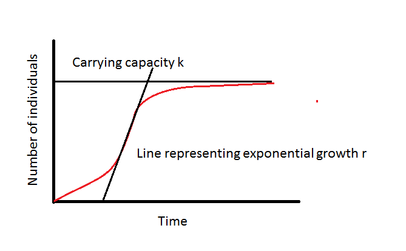

# R/ RStudio Orientation

- Script, Console, Environment, Help
- R basics
  - making objects
  - Object types
    - numeric, character, factor, vector, data.frame, list
  - for loop
  - functions
    - c() and trick to building a recursive vector
    - head() and tail()

# Pipeline

We will be following this vignette: [Growthcurver](https://cran.r-project.org/web/packages/growthcurver/vignettes/Growthcurver-vignette.html)

## Pipeline breakdown:

1. Setup script
2. Load data
3. Organize data for growthcurver
4. Run growthcurver
5. Plot growthcurver output
6. PCA & plot
7. Sigma histogram
8. Plot parameters

## LAA-E2.xlsx

### 1. Setup script

```r
options(stringsAsFactors = F)
#total wells
tw<-96
#filename
fn<-"data/LAA-E2//LAA-E2.xlsx"
#replicates?
x<-3
#number of antibiotic concentrations
nc<-12
#number of strains #JUST AURLI
ns<-1
```

### 2. Load data

what does allSheets look like?

```r
head(allSheets)
```

```
## [[1]]
##                    X1     X2     X3                    X4     X5     X6     X7
## 1 0.12039999663829803 0.1048 0.1258 4.1600000113248825E-2 0.3008 0.0633 0.0818
## 2 0.11410000175237656 0.1026 0.0740 4.1900001466274261E-2 0.3547 0.0886 0.0513
## 3 0.15479999780654907 0.3871 0.1990 4.2399998754262924E-2 0.3708 0.0930 0.3193
##       X8     X9    X10    X11    X12
## 1 0.0867 0.0402 0.0405 0.0412 0.0417
## 2 0.0795 0.0408 0.0399 0.0406 0.0377
## 3 0.1449 0.0432 0.0412 0.0413 0.0383
##
## [[2]]
##                    X1     X2     X3                    X4     X5     X6     X7
## 1 0.11909999698400497 0.1062 0.0844 4.2300000786781311E-2 0.1620 0.0719 0.0816
## 2 0.11140000075101852 0.1075 0.0781 4.3000001460313797E-2 0.2569 0.0997 0.0548
## 3 0.13729999959468842 0.4071 0.1357 4.2399998754262924E-2 0.3938 0.1064 0.3070
##       X8     X9    X10    X11    X12
## 1 0.0793 0.0403 0.0402 0.0420 0.0429
## 2 0.0704 0.0410 0.0403 0.0410 0.0400
## 3 0.1479 0.0441 0.0415 0.0413 0.0401
##
## [[3]]
##                    X1     X2     X3                    X4     X5     X6     X7
## 1 0.13989999890327454 0.1136 0.0856 4.2199999094009399E-2 0.3861 0.0829 0.0795
## 2 0.12649999558925629 0.1171 0.0841 4.2300000786781311E-2 0.3864 0.0913 0.0599
## 3 0.14830000698566437 0.2604 0.2013 4.2899999767541885E-2 0.3947 0.0852 0.3083
##       X8     X9    X10    X11    X12
## 1 0.0819 0.0401 0.0401 0.0414 0.0421
## 2 0.0696 0.0406 0.0397 0.0405 0.0376
## 3 0.1540 0.0429 0.0410 0.0418 0.0398
##
## [[4]]
##                    X1     X2     X3                    X4     X5     X6     X7
## 1 0.15250000357627869 0.1372 0.1218 4.1600000113248825E-2 0.3019 0.0786 0.0930
## 2 0.13709999620914459 0.1185 0.0773 4.2800001800060272E-2 0.2143 0.1003 0.0646
## 3 0.15919999778270721 0.2336 0.1178  4.179999977350235E-2 0.1694 0.0865 0.3090
##       X8     X9    X10    X11    X12
## 1 0.0814 0.0396 0.0403 0.0412 0.0422
## 2 0.0649 0.0404 0.0394 0.0400 0.0375
## 3 0.1615 0.0433 0.0414 0.0406 0.0400
##
## [[5]]
##                    X1     X2     X3                    X4     X5     X6     X7
## 1 0.13910000026226044 0.1487 0.1088 4.2599998414516449E-2 0.5629 0.0702 0.0983
## 2 0.14309999346733093 0.1674 0.0946 4.2599998414516449E-2 0.3192 0.0948 0.0976
## 3 0.15590000152587891 0.3082 0.1106 4.2500000447034836E-2 0.2431 0.0848 0.2882
##       X8     X9    X10    X11    X12
## 1 0.0900 0.0393 0.0399 0.0410 0.0423
## 2 0.0815 0.0399 0.0387 0.0403 0.0374
## 3 0.1692 0.0427 0.0405 0.0409 0.0397
##
## [[6]]
##                    X1     X2     X3                    X4     X5     X6     X7
## 1 0.14440000057220459 0.2028 0.2612 4.2800001800060272E-2 0.2403 0.0790 0.1046
## 2 0.21119999885559082 0.3508 0.2559 4.3200001120567322E-2 0.3552 0.0904 0.1284
## 3 0.21480000019073486 0.3166 0.1800 4.3000001460313797E-2 0.4675 0.0859 0.2817
##       X8     X9    X10    X11    X12
## 1 0.1571 0.0400 0.0402 0.0413 0.0457
## 2 0.0903 0.0402 0.0396 0.0397 0.0374
## 3 0.1775 0.0435 0.0409 0.0409 0.0400
```

### 3. Organize data for growthcurver

```r
#reverse list order for excel files in reverse chronological order
library("rlist")
allSheets1<-list.reverse(allSheets)

#calculate difference in time
sto1.t<-list()
for (i in 1:c(length(excel_sheets(fn)))) {
  sto.t<-read.csv(paste("t", paste(i),".csv", sep= ""), header = F, skip = 22, nrow = 1, stringsAsFactors=FALSE)
  #date & time
  sto.t<-sto.t[1,2]
  #strsplit date & replace "/" with "-"
  date<-gsub("/", "-", paste((strsplit(sto.t, " ")[[1]][(1)]), collapse = " "))
  #date format from m-d-y to y-m-d
  y<-(strsplit(date, "-")[[1]][(3)])
  m<-(strsplit(date, "-")[[1]][(1)])
  d<-(strsplit(date, "-")[[1]][(2)])
  tdate<-paste(y, m,d, sep = "-")
  #put into list
  sto1.t[[i]]<-tdate
  #strsplit time
  t<-paste((strsplit(sto.t, " ")[[1]][(2:3)]), collapse = " ")
  #change 12H to 24H
  ttime<-format(strptime(t, "%I:%M:%S %p"), format="%H:%M:%S")
  sto1.t[[i]][2]<-ttime
}
sto1.t<-list.reverse(sto1.t)
tdif<-c()
for (i in 2:length(sto1.t)) {
  dif<-difftime(paste(sto1.t[[i]][1],sto1.t[[i]][2], sep = " "), paste(sto1.t[[1]][1],sto1.t[[1]][2], sep = " "), units = "hours")
  tdif<-c(tdif, dif)
}
tdif<-c(0,tdif)
```

what does tdif look like?

```r
head(tdif)
```

```
## [1]  0.00000000  0.03861111  0.06833333 10.10916667 26.64194444 32.69777778
```

```r
#create the data.frame structure and column names
u<-data.frame(time=c(tdif))
ro<-c("A","B","C")
co<-c(1:12)

df<-c() #makes a vector of all the well names used in 'ro' and 'co'
for (i in (unique(ro))) {
  for (j in (unique(co))) {
    df<-c(df,paste(i,j,sep=""))
  }
}

for (i in 1:length(df)) { #creates each well name to be a vector in existence
  assign(df[i], c(recursive = TRUE))
}

for (i in 1:length(df)) { #assigns vector of well name and column of u with data of each time point at well placement
  for (j in 1:length(allSheets1)) {
    assign(df[i], c(get(df[i]),as.numeric(c(allSheets1[[j]][1,],allSheets1[[j]][2,],allSheets1[[j]][3,]))[i])) # makes a vector of data to sleect based on df[i] // optimization required here for more than three rows
  }
  u[,(i+1)]<-get(df[i])
}

colnames(u)<-c("time",df) #give each column the corresponding well name
```

what does u look like?

```r
head(u)
```

```
##          time     A1     A2     A3     A4     A5     A6     A7     A8     A9
## 1  0.00000000 0.0374 0.0384 0.0387 0.0443 0.0396 0.0388 0.0385 0.0383 0.0422
## 2  0.03861111 0.0389 0.0379 0.0395 0.0449 0.0406 0.0389 0.0385 0.0383 0.0387
## 3  0.06833333 0.0391 0.0390 0.0400 0.0462 0.0416 0.0389 0.0395 0.0387 0.0402
## 4 10.10916667 0.0412 0.0687 0.0531 0.0440 0.1019 0.0392 0.0391 0.0394 0.0396
## 5 26.64194444 0.0722 0.2227 0.2097 0.0431 0.2064 0.0402 0.0400 0.0393 0.0400
## 6 32.69777778 0.2557 0.3649 0.3604 0.0433 0.3539 0.0423 0.0396 0.0396 0.0401
##      A10    A11    A12     B1     B2     B3     B4     B5     B6     B7     B8
## 1 0.0387 0.0404 0.0443 0.0406 0.0408 0.0405 0.0464 0.0402 0.0398 0.0394 0.0394
## 2 0.0379 0.0398 0.0418 0.0394 0.0443 0.0401 0.0463 0.0401 0.0393 0.0385 0.0393
## 3 0.0385 0.0403 0.0421 0.0402 0.0462 0.0404 0.0495 0.0401 0.0452 0.0393 0.0399
## 4 0.0393 0.0424 0.0403 0.0406 0.0456 0.0400 0.0439 0.0418 0.0390 0.0389 0.0397
## 5 0.0397 0.0411 0.0407 0.2426 0.2187 0.2089 0.0450 0.2000 0.0397 0.0395 0.0398
## 6 0.0396 0.0410 0.0431 0.3796 0.3554 0.3351 0.0441 0.3268 0.0404 0.0536 0.0407
##       B9    B10    B11    B12     C1     C2     C3     C4     C5     C6     C7
## 1 0.0400 0.0393 0.0400 0.0397 0.0418 0.0390 0.0408 0.0474 0.0416 0.0416 0.0422
## 2 0.0402 0.0395 0.0407 0.0395 0.0457 0.0392 0.0446 0.0482 0.0405 0.0397 0.0404
## 3 0.0405 0.0400 0.0416 0.0409 0.0417 0.0411 0.0462 0.0499 0.0412 0.0402 0.0402
## 4 0.0396 0.0390 0.0398 0.0384 0.0429 0.0555 0.0426 0.0443 0.0410 0.0404 0.0403
## 5 0.0402 0.0394 0.0409 0.0396 0.2355 0.2128 0.2013 0.0451 0.1968 0.0417 0.0412
## 6 0.0406 0.0384 0.0393 0.0381 0.3752 0.3622 0.3272 0.0441 0.3167 0.0411 0.0419
##       C8     C9    C10    C11    C12
## 1 0.0411 0.0418 0.0402 0.0398 0.0412
## 2 0.0419 0.0430 0.0395 0.0400 0.0397
## 3 0.0412 0.0433 0.0404 0.0400 0.0405
## 4 0.0422 0.0426 0.0398 0.0405 0.0390
## 5 0.0421 0.0433 0.0404 0.0408 0.0394
## 6 0.0418 0.0437 0.0400 0.0410 0.0402
```